# Elements Of Data Visualization: Project 2, Exoplanet Analysis

**By Jose Cortez, Adam Hernandex, and Alex Pearce**

**GitHub**: https://github.com/joseacortez91/DV_RProject2

This project deals with creating interesting graphs of exoplanet data from this [research paper](http://adsabs.harvard.edu/abs/2014PASP..126..827H), using packages like tidyr and dplyr as well as our standard class packages to form data frames and visualizations. In accordance with our usage of the information, we would like to acknowledge that *this research has made use of the Exoplanet Orbit Database and the Exoplanet Data Explorer at exoplanets.org*.

## Load necessary packages

```r
source("../01 Data/load_packages.R",echo=TRUE)
```

```
##
## > library("ggplot2")
##
## > library("gplots")
##
## > library("grid")
##
## > library("plyr")
##
## > library("RCurl")
##
## > library("reshape2")
##
## > library("dplyr")
```

## Database Creations

```r
source("../01 Data/create-df.R",echo=TRUE)
```

```
##
## > df <- data.frame(eval(parse(text = substring(getURL(URLencode("http://129.152.144.84:5001/rest/native/?query=\"select * from exoplanets\""),
## +      .... [TRUNCATED]
##
## > earth.df <- filter(df, RADIUS != "null" & MASS !=
## +     "null") %>% transform(ECCENTRICITY = as.numeric(as.character(ECCENTRICITY))) %>%
## +     tra .... [TRUNCATED]
```

```
##
## > df <- filter(df, RADIUS != "null" & MASS != "null" &
## +     ORB_PERIOD != "null" & ECCENTRICITY != "null") %>% transform(ECCENTRICITY = as.numeric(a .... [TRUNCATED]
##
## > radial.df <- df
##
## > tbl_df(df)
## Source: local data frame [298 x 5]
##
##            NAME        MASS    RADIUS ORB_PERIOD ECCENTRICITY
## 1   Kepler-43 b  3.23143005 1.2000000   3.024095        0.000
## 2      KELT-6 b  0.43122000 1.1930000   7.845700        0.220
## 3     WASP-13 b  0.47388300 1.4069999   4.353014        0.000
## 4    HAT-P-18 b  0.19720501 0.9950000   5.508023        0.084
## 5  Kepler-406 c  0.00857506 0.0758319   4.623320        0.000
## 6     WASP-43 b  1.77609003 0.9300000   0.813475        0.000
## 7   Kepler-39 b 18.18050003 1.2200000  21.087400        0.121
## 8   Kepler-29 b  0.03971210 0.3208840  10.337600        0.000
## 9   Kepler-24 b  0.01850710 0.2139230   8.145610        0.000
## 10    CoRoT-3 b 21.85490036 1.0100000   4.256800        0.000
## ..          ...         ...       ...        ...          ...
```

# Average Mass and Radius Analysis

We will begin by ordering the exoplanets by mass and dividing them into ten groups, which we will call percentiles. Each mass percentile will then be summarized to generate the average mass and radius of the percentile. Plotting these results will compare how average mass and radius change for each percentile, thus showing if there is a radical difference in mass/radius between the discovered exoplanets.

## Data Wrangling

```r
source("../02 Data Wrangling/mass_radius.R",echo=TRUE)
```

```
##
## > massAndRadius.df <- radial.df %>% select(NAME, MASS,
## +     RADIUS) %>% mutate(MASS_PERCENTILE = paste(10 * ntile(cume_dist(MASS),
## +     10) - 10,  .... [TRUNCATED]
```

## Visualization

```r
source("../03 Visualizations/mass_radius_analysis.R", echo=TRUE)
```

```
##
## > massAndRadius.df %>% ggplot(aes(x = MASS_PERCENTILE,
## +     y = AVG_MASS, color = AVG_RADIUS)) + geom_point(na.rm = TRUE) +
## +     scale_y_continuou .... [TRUNCATED]
```

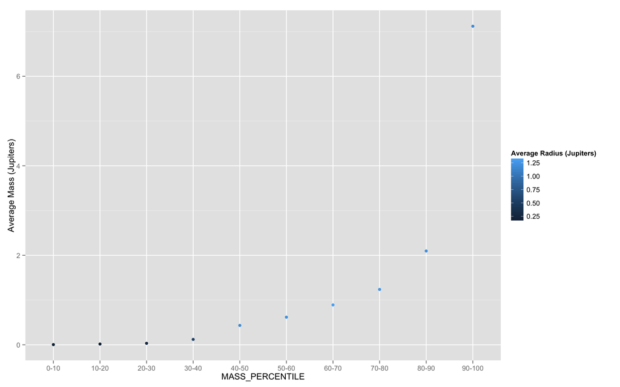

# Orbital Eccentricity Analysis

Via Wikipedia:

> The orbital eccentricity of an astronomical object is a parameter that determines the amount by which its orbit around another body deviates from a perfect circle. A value of 0 is a circular orbit, values between 0 and 1 form an elliptical orbit, 1 is a parabolic escape orbit, and greater than 1 is a hyperbola. The term derives its name from the parameters of conic sections, as every Kepler orbit is a conic section. It is normally used for the isolated two-body problem, but extensions exist for objects following a rosette orbit through the galaxy.

How incredibly interesting. This portion of project 2 deals with analyzing exoplanets of individual solar systems along with their average mass, eccentricity, and orbital period. By using data-wrangling, subsetting the data for this desired visualization was done with ease. We first “zoom-in” to the data by looking at solar systems with more than one planet then “zoom-out” by including all solar-systems.

## Data Wrangling

```r
source("../02 Data Wrangling/eccentricity.R",echo=TRUE)
```

```
##
## > eccen.df <- filter(df, RADIUS != "null" & MASS !=
## +     "null" & ORB_PERIOD != "null" & ECCENTRICITY != "null") %>%
## +     mutate(STAR = sub(".$",  .... [TRUNCATED]
##
## > eccen2.df <- filter(df, RADIUS != "null" & MASS !=
## +     "null" & ORB_PERIOD != "null" & ECCENTRICITY != "null") %>%
## +     mutate(STAR = sub(".$", .... [TRUNCATED]
##
## > tbl_df(eccen2.df)
## Source: local data frame [238 x 7]
##
##         STAR Mean_Eccentricty Mean_Orb_Period Mean_mass Planets
## 1    55 Cnc              0.00        0.736546 0.0263671       1
## 2   CoRoT-1              0.00        1.508956 1.0297900       1
## 3  CoRoT-10              0.53       13.240600 2.7553599       1
## 4  CoRoT-11              0.00        2.994330 2.3481300       1
## 5  CoRoT-12              0.07        2.828042 0.9191800       1
## 6  CoRoT-13              0.00        4.035190 1.3109900       1
## 7  CoRoT-14              0.00        1.512140 7.6946402       1
## 8  CoRoT-16              0.33        5.352270 0.5379820       1
## 9  CoRoT-17              0.00        3.768100 2.4600101       1
## 10 CoRoT-18              0.04        1.900069 3.4865201       1
## ..       ...              ...             ...       ...     ...
## Variables not shown: Mass_Cume_Dist (dbl), Mass (int)
```

After all null values are filtered out, the STAR column is created by ommiting the last character of the NAMES column in order to provide duplicate values for planets in the same solar system.

This output is piped for selection of the STAR, ECCENTRICITY, ORB_PERIOD, and MASS columns.

Subsequent groupby and summarise functions group the planets into their respective stars, and returns the mean of the variables in question.

Finally, for ease of representing the mean cummulative distribution of planet mass per star, the mass data is piped first with cumme _ dist followed by the ntile function to separate the quantiles of the distribution.

This Is done yet again for the second graph, yet the filter(Planets >1) workflow portion is ommited.

## Visualizations

```r
source("../03 Visualizations/eccen_analysis_1.R", echo=TRUE)
```

```
##
## > qplot(Mean_Orb_Period, Mean_Eccentricty, data = eccen.df,
## +     size = Mass, color = factor(Planets)) + scale_size(name = "Average Mass",
## +     br .... [TRUNCATED]
```

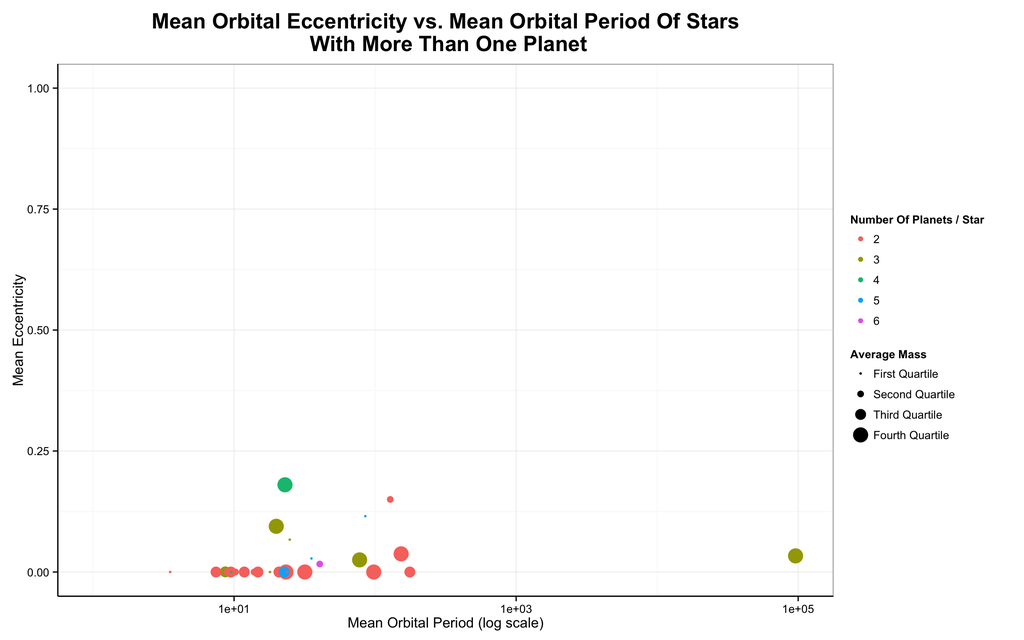

```r
source("../03 Visualizations/eccen_analysis_2.R", echo=TRUE)
```

```
##
## > qplot(Mean_Orb_Period, Mean_Eccentricty, data = eccen2.df,
## +     size = Mass, color = Planets) + scale_size(name = "Average Mass",
## +     breaks =  .... [TRUNCATED]
```

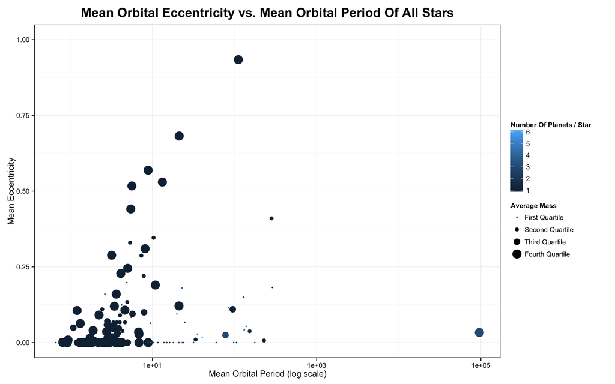

Comparing the two graphs, it can be seen that variation in Mean Eccentricty vs. Mean Orbital Period is much greater when considering single-planet stars. Perhaps the number of planets in a solar system have an effect on how closely planets will form a more cirular orbit? Moreover, there appears to be a positive correlation with eccentricity and orbital period, but it’s difficult to discern much else without proper statisical analysis and applicable physics knowledge!

# Exoplanet comparison with Earth

## Data Wrangling

### Narrow dataframe results to exoplanets within 10% of Earth’s mass and radius

```r
source("../02 Data Wrangling/earth.R",echo=TRUE)
```

```
##
## > earth.df <- earth.df %>% filter(RADIUS <= 0.096 &
## +     RADIUS >= 0.087 & MASS >= 0.00283 & MASS <= 0.00346) %>%
## +     select(NAME, MASS, RADIUS,  .... [TRUNCATED]
##
## > tbl_df(earth.df)
## Source: local data frame [13 x 5]
##
##            NAME       MASS    RADIUS ORB_PERIOD ECCENTRICITY
## 1  Kepler-271 c 0.00291583 0.0892140   7.410935           NA
## 2  Kepler-387 b 0.00324127 0.0918904   6.791636           NA
## 3  Kepler-130 b 0.00313003 0.0909983   8.457458           NA
## 4  Kepler-398 c 0.00302153 0.0901062  11.419412           NA
## 5  Kepler-322 b 0.00302153 0.0901062   1.653888           NA
## 6  Kepler-395 b 0.00324127 0.0918904   7.054346           NA
## 7  Kepler-327 c 0.00324127 0.0918904   5.212333           NA
## 8   Kepler-20 f 0.00323095 0.0918085  19.577061            0
## 9  Kepler-392 b 0.00291583 0.0892140   5.341853           NA
## 10 Kepler-374 b 0.00324127 0.0918904   1.897806           NA
## 11 Kepler-197 b 0.00313003 0.0909983   5.599308           NA
## 12 Kepler-336 b 0.00313003 0.0909983   2.024823           NA
## 13 Kepler-282 b 0.00302153 0.0901062   9.220524           NA
```

### Plot these Earth-like exoplanets on a graph

```r
source("../03 Visualizations/earth_analysis.R", echo=TRUE)
```

```
##
## > earth.df %>% ggplot(aes(x = RADIUS, y = ORB_PERIOD,
## +     size = MASS)) + geom_point()
```

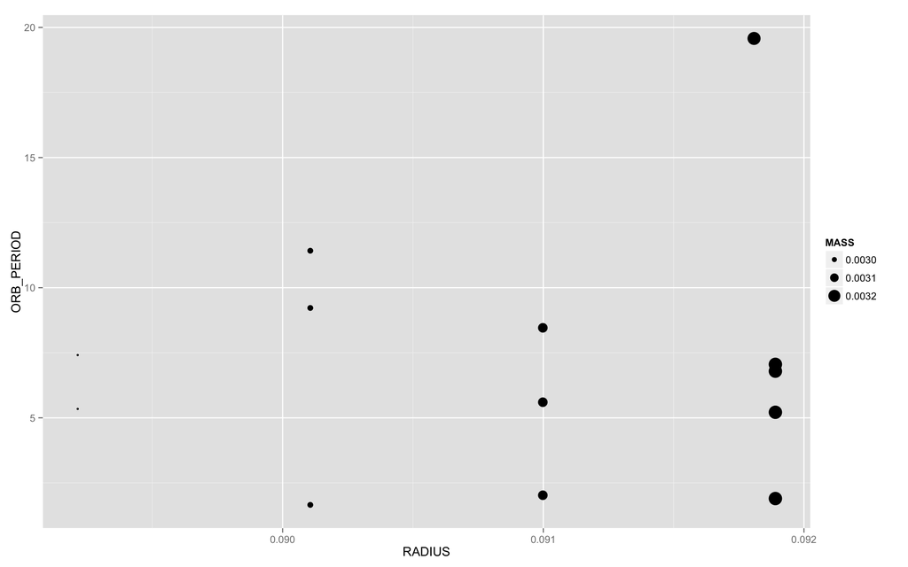

This plot displays all scientifically known exoplanets which have mass and radius to within 10% of Earth’s. The units of radius and mass are in terms of Jupiter’s radius and mass. The Orbital period is also shown and for each planet this value falls far short of Earth’s 365 day cycle. A human would age much quicker on any of these exoplanets!